# MGCFA Example

Erin M. Buchanan

9/17/2019

# Overview

- This video covers an example of Multigroup Confirmatory Factor Analysis (MGCFA)
- This video is part of my structural equation modeling series:
  - https://www.youtube.com/watch?v=JEFMdQrXwJc&list=PLw93TUuxrFAZkJVc5dhgTZpOT7qmTjlT7
  - https://www.youtube.com/watch?v=tmpFrygKTUQ&list=PLw93TUuxrFAZV3ZgsNfMFszE8OA744NnQ
- This video is an update because of changes in the *semTools* package, as well new information on equivalence testing

# Assumptions

- You know something about structural equation modeling
- You’ve got an idea about multigroup models
  - Lecture: https://youtu.be/W4fkW-tqIUg
- You’ve learned a bit of *lavaan* syntax

# Let’s get started!

- Equality constraints
- We’ve talked before about setting paths equal to each other by calling them the same parameter name
  - cheese =~ a*feta + a*swiss
  - So feta and swiss will be estimated at the same value.
- The entire purpose of a multigroup model is to build equality constraints
- We could do this one at a time, ourselves, or use the *semTools* package to build these

# An Example

- Using the RS-14 scale: a one-factor measure of resiliency

```r
##libraries
library(lavaan)
##data
master <- read.csv("mgcfa RS.csv")

head(master)
```

```
##   Sex race_test Ethnicity RS1 RS2 RS3 RS4 RS5 RS6 RS7 RS8 RS9 RS10 RS11
## 1   2         0         8   4   4   4   4   4   4   4   4   4    4    4
## 2   1         0         5   5   2   6   4   4   5   4   5   5    4    4
## 3   2         0         9   7   7   7   7   2   7   7   4   3    7    7
## 4   2         0         8   7   6   6   7   7   7   7   7   7    7    7
## 5   1         0         4   2   2   2   2   2   2   2   2   2    2    2
## 6   2         0         4   4   5   5   7   5   7   5   7   5    4    5
##   RS12 RS13 RS14
## 1    4    4    4
## 2    6    4    4
## 3    5    7    5
## 4    6    7    7
## 5    2    2    2
## 6    6    6    5
```

# Clean up the data

- By not including other labels, we are dropping those categories

```r
master$Sex <- factor(master$Sex,
                     levels = c(1,2),
                     labels = c("Men", "Women"))
table(master$Sex)
```

```
##
##   Men Women
##   244   266
```

```r
master <- subset(master,
                 !is.na(Sex))
```

# Start with Overall CFA

- NEW: `meanstructure = TRUE`
- Gives you the intercepts and means in the model.
- You want to turn that one at the beginning, and you are first examining models with means, so you can tell if you have bad parameters at the start.

# Start with Overall CFA

```r
overall.model <- '
RS =~ RS1 + RS2 + RS3 + RS4 + RS5 + RS6 + RS7 + RS8 + RS9 + RS10 + RS11 + RS12 + RS13 + RS14
'

overall.fit <- cfa(model = overall.model,
                   data = master,
                   meanstructure = TRUE) ##this is important
```

# Examine Overall Fit

```r
summary(overall.fit,
        standardized = TRUE,
        rsquare = TRUE,
        fit.measure = TRUE)
```

```
## lavaan 0.6-5 ended normally after 26 iterations
##
##   Estimator                                         ML
##   Optimization method                           NLMINB
##   Number of free parameters                         42
##
##   Number of observations                           510
##
## Model Test User Model:
##
##   Test statistic                               368.984
##   Degrees of freedom                                77
##   P-value (Chi-square)                           0.000
##
## Model Test Baseline Model:
##
##   Test statistic                              4064.761
##   Degrees of freedom                                91
##   P-value                                        0.000
##
## User Model versus Baseline Model:
##
##   Comparative Fit Index (CFI)                    0.927
##   Tucker-Lewis Index (TLI)                       0.913
##
## Loglikelihood and Information Criteria:
##
##   Loglikelihood user model (H0)             -13050.226
##   Loglikelihood unrestricted model (H1)     -12865.734
##
##   Akaike (AIC)                               26184.452
##   Bayesian (BIC)                             26362.297
##   Sample-size adjusted Bayesian (BIC)        26228.983
##
## Root Mean Square Error of Approximation:
##
##   RMSEA                                          0.086
##   90 Percent confidence interval - lower         0.078
##   90 Percent confidence interval - upper         0.095
##   P-value RMSEA <= 0.05                          0.000
```

[output cut: 66 more lines]

```
##                    Estimate
##     RS1               0.406
##     RS2               0.470
##     RS3               0.411
##     RS4               0.438
##     RS5               0.414
##     RS6               0.535
##     RS7               0.564
##     RS8               0.497
##     RS9               0.555
##     RS10              0.507
##     RS11              0.561
##     RS12              0.467
##     RS13              0.572
##     RS14              0.675
```

# Make a table of fit indices

```r
table_fit <- matrix(NA, nrow = 9, ncol = 6)
colnames(table_fit) = c("Model", "X2", "df", "CFI", "RMSEA", "SRMR")
table_fit[1, ] <- c("Overall Model", round(fitmeasures(overall.fit,
                                                 c("chisq", "df", "cfi",
                                                   "rmsea", "srmr")),3))
kable(table_fit)
```

| Model | X2 | df | CFI | RMSEA | SRMR |
| --- | --- | --- | --- | --- | --- |
| Overall Model | 368.984 | 77 | 0.927 | 0.086 | 0.041 |
| NA | NA | NA | NA | NA | NA |
| NA | NA | NA | NA | NA | NA |
| NA | NA | NA | NA | NA | NA |
| NA | NA | NA | NA | NA | NA |
| NA | NA | NA | NA | NA | NA |
| NA | NA | NA | NA | NA | NA |
| NA | NA | NA | NA | NA | NA |
| NA | NA | NA | NA | NA | NA |

# Create a Picture

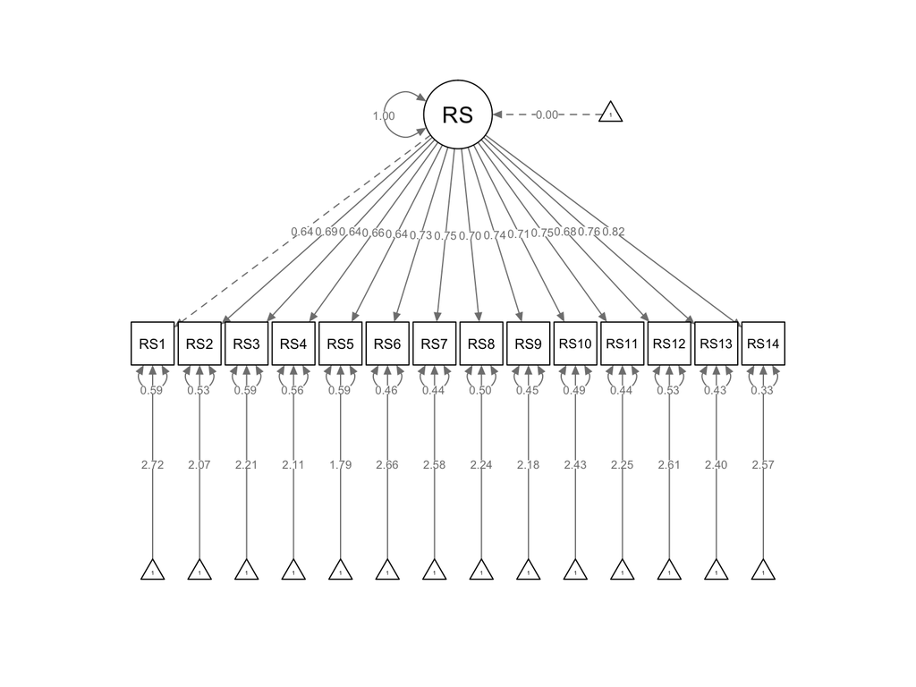

```r
library(semPlot)
semPaths(overall.fit,
         whatLabels = "std",
         layout = "tree")
```

# The `equaltestMI` package

```r
library(equaltestMI)

MG.model <- eqMI.main(model = overall.model,
                      data = master,
                      group = "Sex",
                      meanstructure = TRUE,
                      output = "both", #mean, covariance, both
                      equivalence.test = FALSE, #change this in a moment
                      adjRMSEA = TRUE, #but see new paper
                      projection = TRUE, #see notes
                      bootstrap = FALSE)
```

```
##
##  ---------- Equality of Population Covariance Matrices under NHT ----------
##
##                Chisq  Df       pvalue
## fit.pop.cov 263.5322 105 1.332268e-15
##
##  ------------------ Covariance Structure ------------------
```

```
##
## Measurement invariance models
##
## Model 1 : fit.configural.g1
## Model 2 : fit.configural.g2
## Model 3 : fit.combine.groups
## Model 4 : fit.metric
## Model 5 : fit.residuals
## Model 6 : fit.varfactor
##
## Chi-Squared Difference Test
##
##                     Df   AIC   BIC  Chisq Chisq diff Df diff Pr(>Chisq)
## fit.configural.g1   77 12171 12318 271.46
## fit.configural.g2   77 13962 14112 258.61
## fit.combine.groups 154 26133 26488 530.07
## fit.metric         167 26122 26423 545.52     15.451      13    0.28002
## fit.residuals      181 26170 26411 620.85     75.331      14  2.057e-10
## fit.varfactor      182 26173 26410 625.89      5.042       1    0.02474
##
## fit.configural.g1
## fit.configural.g2
## fit.combine.groups
## fit.metric
## fit.residuals      ***
## fit.varfactor      *
## ---
## Signif. codes:  0 '***' 0.001 '**' 0.01 '*' 0.05 '.' 0.1 ' ' 1
##
##  Fit measures
##
##                         cfi    rmsea cfi.delta rmsea.delta
## fit.configural.g1     0.920    0.102
## fit.configural.g2     0.895    0.094
## fit.combine.groups    0.909    0.098
## fit.metric            0.909    0.094     0.001       0.004
## fit.residuals         0.894    0.098     0.015       0.003
## fit.varfactor         0.893    0.098     0.001       0.000
##
##
```

[output cut: 48 more lines]

```
## fit.metric            545.518 167    0.000     15.451      13    0.280
## fit.residuals         620.849 181    0.000     75.331      14    0.000
## fit.varfactor         625.891 182    0.000      5.042       1    0.025
## fit.scalar            585.327 180    0.000     39.808      13    0.000
## fit.strong.means      585.589 181    0.000      0.262       1    0.609
## fit.strict.residuals  660.398 194    0.000     75.071      14    0.000
## fit.strict.means      660.652 195    0.000      0.254       1    0.614
##
##  ---------- Means of Latent and Specific Factors by the Projection Method and under NHT ----------
##
##                  Chisq Df       pvalue
## fit.mvmean   39.956192 14 2.591665e-04
## fit.common    0.124723  1 1.000000e+00
## fit.specific 39.692055 13 2.973326e-10
## Validity Index is 0.04224111
```

# Examine and Update Results

- You would first examine each group separately to see fit
- All the models you could potentially want to run are saved with the `eqMI.main` function
- Let’s work through the Brown style steps to see how we can pull all the information we’d want

# Men Overall Summary

```r
##Men
summary(MG.model$convention.sem$LavaanOut$fit.configural.g1, ##each model saved here
        standardized = TRUE,
        rsquare = TRUE,
        fit.measure = TRUE)
```

```
## lavaan 0.6-5 ended normally after 25 iterations
##
##   Estimator                                         ML
##   Optimization method                           NLMINB
##   Number of free parameters                         42
##
##   Number of observations                           244
##
## Model Test User Model:
##
##   Test statistic                               271.457
##   Degrees of freedom                                77
##   P-value (Chi-square)                           0.000
##
## Model Test Baseline Model:
##
##   Test statistic                              2515.572
##   Degrees of freedom                                91
##   P-value                                        0.000
##
## User Model versus Baseline Model:
##
##   Comparative Fit Index (CFI)                    0.920
##   Tucker-Lewis Index (TLI)                       0.905
##
## Loglikelihood and Information Criteria:
##
##   Loglikelihood user model (H0)              -6043.672
##   Loglikelihood unrestricted model (H1)      -5907.944
##
##   Akaike (AIC)                               12171.345
##   Bayesian (BIC)                             12318.226
##   Sample-size adjusted Bayesian (BIC)        12185.091
##
## Root Mean Square Error of Approximation:
##
##   RMSEA                                          0.102
##   90 Percent confidence interval - lower         0.089
##   90 Percent confidence interval - upper         0.115
##   P-value RMSEA <= 0.05                          0.000
```

[output cut: 66 more lines]

```
##                    Estimate
##     RS1               0.491
##     RS2               0.570
##     RS3               0.482
##     RS4               0.485
##     RS5               0.454
##     RS6               0.543
##     RS7               0.554
##     RS8               0.617
##     RS9               0.664
##     RS10              0.570
##     RS11              0.612
##     RS12              0.625
##     RS13              0.695
##     RS14              0.700
```

# Women Overall Summary

```r
##Women
summary(MG.model$convention.sem$LavaanOut$fit.configural.g2, ##each model saved here
        standardized = TRUE,
        rsquare = TRUE,
        fit.measure = TRUE)
```

```
## lavaan 0.6-5 ended normally after 29 iterations
##
##   Estimator                                         ML
##   Optimization method                           NLMINB
##   Number of free parameters                         42
##
##   Number of observations                           266
##
## Model Test User Model:
##
##   Test statistic                               258.610
##   Degrees of freedom                                77
##   P-value (Chi-square)                           0.000
##
## Model Test Baseline Model:
##
##   Test statistic                              1813.360
##   Degrees of freedom                                91
##   P-value                                        0.000
##
## User Model versus Baseline Model:
##
##   Comparative Fit Index (CFI)                    0.895
##   Tucker-Lewis Index (TLI)                       0.875
##
## Loglikelihood and Information Criteria:
##
##   Loglikelihood user model (H0)              -6938.738
##   Loglikelihood unrestricted model (H1)      -6809.434
##
##   Akaike (AIC)                               13961.477
##   Bayesian (BIC)                             14111.984
##   Sample-size adjusted Bayesian (BIC)        13978.820
##
## Root Mean Square Error of Approximation:
##
##   RMSEA                                          0.094
##   90 Percent confidence interval - lower         0.082
##   90 Percent confidence interval - upper         0.107
##   P-value RMSEA <= 0.05                          0.000
```

[output cut: 66 more lines]

```
##                    Estimate
##     RS1               0.314
##     RS2               0.369
##     RS3               0.339
##     RS4               0.404
##     RS5               0.388
##     RS6               0.538
##     RS7               0.583
##     RS8               0.389
##     RS9               0.466
##     RS10              0.446
##     RS11              0.503
##     RS12              0.331
##     RS13              0.460
##     RS14              0.660
```

# Add the fit to table

```r
table_fit[2, ] <- c("Men Model", round(fitmeasures(MG.model$convention.sem$LavaanOut$fit.configural.g1,
                                                 c("chisq", "df", "cfi",
                                                   "rmsea", "srmr")),3))

table_fit[3, ] <- c("Women Model", round(fitmeasures(MG.model$convention.sem$LavaanOut$fit.configural.g2,
                                                 c("chisq", "df", "cfi",
                                                   "rmsea", "srmr")),3))

kable(table_fit)
```

| Model | X2 | df | CFI | RMSEA | SRMR |
| --- | --- | --- | --- | --- | --- |
| Overall Model | 368.984 | 77 | 0.927 | 0.086 | 0.041 |
| Men Model | 271.457 | 77 | 0.92 | 0.102 | 0.041 |
| Women Model | 258.61 | 77 | 0.895 | 0.094 | 0.052 |
| NA | NA | NA | NA | NA | NA |
| NA | NA | NA | NA | NA | NA |
| NA | NA | NA | NA | NA | NA |
| NA | NA | NA | NA | NA | NA |
| NA | NA | NA | NA | NA | NA |
| NA | NA | NA | NA | NA | NA |

# Configural Invariance

- Both groups “pancaked” together

```r
summary(MG.model$convention.sem$LavaanOut$fit.combine.groups, ##each model saved here
        standardized = TRUE,
        rsquare = TRUE,
        fit.measure = TRUE)
```

```
## lavaan 0.6-5 ended normally after 49 iterations
##
##   Estimator                                         ML
##   Optimization method                           NLMINB
##   Number of free parameters                         84
##
##   Number of observations per group:
##     Women                                          266
##     Men                                            244
##
## Model Test User Model:
##
##   Test statistic                               530.067
##   Degrees of freedom                               154
##   P-value (Chi-square)                           0.000
##   Test statistic for each group:
##     Women                                      258.610
##     Men                                        271.457
##
## Model Test Baseline Model:
##
##   Test statistic                              4328.931
##   Degrees of freedom                               182
##   P-value                                        0.000
##
## User Model versus Baseline Model:
##
##   Comparative Fit Index (CFI)                    0.909
##   Tucker-Lewis Index (TLI)                       0.893
##
## Loglikelihood and Information Criteria:
##
##   Loglikelihood user model (H0)             -12982.411
##   Loglikelihood unrestricted model (H1)     -12717.377
##
##   Akaike (AIC)                               26132.822
##   Bayesian (BIC)                             26488.512
##   Sample-size adjusted Bayesian (BIC)        26221.885
##
## Root Mean Square Error of Approximation:
```

[output cut: 148 more lines]

```
##                    Estimate
##     RS1               0.491
##     RS2               0.570
##     RS3               0.482
##     RS4               0.485
##     RS5               0.454
##     RS6               0.543
##     RS7               0.554
##     RS8               0.617
##     RS9               0.664
##     RS10              0.570
##     RS11              0.612
##     RS12              0.625
##     RS13              0.695
##     RS14              0.700
```

# Add the fit to table

```r
table_fit[4, ] <- c("Configural Model", round(fitmeasures(MG.model$convention.sem$LavaanOut$fit.combine.groups,
                                                 c("chisq", "df", "cfi",
                                                   "rmsea", "srmr")),3))

kable(table_fit)
```

| Model | X2 | df | CFI | RMSEA | SRMR |
| --- | --- | --- | --- | --- | --- |
| Overall Model | 368.984 | 77 | 0.927 | 0.086 | 0.041 |
| Men Model | 271.457 | 77 | 0.92 | 0.102 | 0.041 |
| Women Model | 258.61 | 77 | 0.895 | 0.094 | 0.052 |
| Configural Model | 530.067 | 154 | 0.909 | 0.098 | 0.047 |
| NA | NA | NA | NA | NA | NA |
| NA | NA | NA | NA | NA | NA |
| NA | NA | NA | NA | NA | NA |
| NA | NA | NA | NA | NA | NA |
| NA | NA | NA | NA | NA | NA |

# What is this doing?

- Two places to change things: 1) model definition, 2) `cfa()` parameters

```r
overall.model
```

```
## [1] "\nRS =~ RS1 + RS2 + RS3 + RS4 + RS5 + RS6 + RS7 + RS8 + RS9 + RS10 + RS11 + RS12 + RS13 + RS14\n"
```

```r
#cfa(model = overall.model,
#   data = master,
#   meanstructure = TRUE,
#   group = "Sex")

MG.model$convention.sem$LavaanOut$fit.combine.groups@call
```

[output not shown]

[output cut: 490 more lines]

[output not shown]

# Metric Invariance

- Are the factor loadings the same?

```r
summary(MG.model$convention.sem$LavaanOut$fit.metric, ##each model saved here
        standardized = TRUE,
        rsquare = TRUE,
        fit.measure = TRUE)
```

```
## lavaan 0.6-5 ended normally after 36 iterations
##
##   Estimator                                         ML
##   Optimization method                           NLMINB
##   Number of free parameters                         84
##   Number of equality constraints                    13
##   Row rank of the constraints matrix                13
##
##   Number of observations per group:
##     Women                                          266
##     Men                                            244
##
## Model Test User Model:
##
##   Test statistic                               545.518
##   Degrees of freedom                               167
##   P-value (Chi-square)                           0.000
##   Test statistic for each group:
##     Women                                      268.133
##     Men                                        277.385
##
## Model Test Baseline Model:
##
##   Test statistic                              4328.931
##   Degrees of freedom                               182
##   P-value                                        0.000
##
## User Model versus Baseline Model:
##
##   Comparative Fit Index (CFI)                    0.909
##   Tucker-Lewis Index (TLI)                       0.901
##
## Loglikelihood and Information Criteria:
##
##   Loglikelihood user model (H0)             -12990.137
##   Loglikelihood unrestricted model (H1)     -12717.377
##
##   Akaike (AIC)                               26122.273
##   Bayesian (BIC)                             26422.916
##   Sample-size adjusted Bayesian (BIC)        26197.552
```

[output cut: 150 more lines]

```
##                    Estimate
##     RS1               0.463
##     RS2               0.561
##     RS3               0.479
##     RS4               0.501
##     RS5               0.473
##     RS6               0.560
##     RS7               0.588
##     RS8               0.603
##     RS9               0.664
##     RS10              0.579
##     RS11              0.631
##     RS12              0.583
##     RS13              0.681
##     RS14              0.699
```

# Add the fit to table

```r
table_fit[5, ] <- c("Metric Model", round(fitmeasures(MG.model$convention.sem$LavaanOut$fit.metric,
                                                 c("chisq", "df", "cfi",
                                                   "rmsea", "srmr")),3))

kable(table_fit)
```

| Model | X2 | df | CFI | RMSEA | SRMR |
| --- | --- | --- | --- | --- | --- |
| Overall Model | 368.984 | 77 | 0.927 | 0.086 | 0.041 |
| Men Model | 271.457 | 77 | 0.92 | 0.102 | 0.041 |
| Women Model | 258.61 | 77 | 0.895 | 0.094 | 0.052 |
| Configural Model | 530.067 | 154 | 0.909 | 0.098 | 0.047 |
| Metric Model | 545.518 | 167 | 0.909 | 0.094 | 0.057 |
| NA | NA | NA | NA | NA | NA |
| NA | NA | NA | NA | NA | NA |
| NA | NA | NA | NA | NA | NA |
| NA | NA | NA | NA | NA | NA |

# What is this doing?

```r
overall.model
```

```
## [1] "\nRS =~ RS1 + RS2 + RS3 + RS4 + RS5 + RS6 + RS7 + RS8 + RS9 + RS10 + RS11 + RS12 + RS13 + RS14\n"
```

```r
#cfa(model = overall.model,
#   data = master,
#   meanstructure = TRUE,
#   group = "Sex",
#   group.equal = c("loadings"))

MG.model$convention.sem$LavaanOut$fit.metric@call
```

[output not shown]

[output cut: 491 more lines]

[output not shown]

# Scalar Invariance

- Are the item intercepts the same?

```r
summary(MG.model$convention.sem$LavaanOut$fit.scalar, ##each model saved here
        standardized = TRUE,
        rsquare = TRUE,
        fit.measure = TRUE)
```

```
## lavaan 0.6-5 ended normally after 47 iterations
##
##   Estimator                                         ML
##   Optimization method                           NLMINB
##   Number of free parameters                         85
##   Number of equality constraints                    27
##   Row rank of the constraints matrix                27
##
##   Number of observations per group:
##     Women                                          266
##     Men                                            244
##
## Model Test User Model:
##
##   Test statistic                               585.327
##   Degrees of freedom                               180
##   P-value (Chi-square)                           0.000
##   Test statistic for each group:
##     Women                                      289.405
##     Men                                        295.921
##
## Model Test Baseline Model:
##
##   Test statistic                              4328.931
##   Degrees of freedom                               182
##   P-value                                        0.000
##
## User Model versus Baseline Model:
##
##   Comparative Fit Index (CFI)                    0.902
##   Tucker-Lewis Index (TLI)                       0.901
##
## Loglikelihood and Information Criteria:
##
##   Loglikelihood user model (H0)             -13010.041
##   Loglikelihood unrestricted model (H1)     -12717.377
##
##   Akaike (AIC)                               26136.082
##   Bayesian (BIC)                             26381.678
##   Sample-size adjusted Bayesian (BIC)        26197.577
```

[output cut: 150 more lines]

```
##                    Estimate
##     RS1               0.462
##     RS2               0.561
##     RS3               0.476
##     RS4               0.494
##     RS5               0.467
##     RS6               0.558
##     RS7               0.588
##     RS8               0.600
##     RS9               0.662
##     RS10              0.579
##     RS11              0.631
##     RS12              0.582
##     RS13              0.681
##     RS14              0.700
```

# Add the fit to table

```r
table_fit[6, ] <- c("Scalar Model", round(fitmeasures(MG.model$convention.sem$LavaanOut$fit.scalar,
                                                 c("chisq", "df", "cfi",
                                                   "rmsea", "srmr")),3))

kable(table_fit)
```

| Model | X2 | df | CFI | RMSEA | SRMR |
| --- | --- | --- | --- | --- | --- |
| Overall Model | 368.984 | 77 | 0.927 | 0.086 | 0.041 |
| Men Model | 271.457 | 77 | 0.92 | 0.102 | 0.041 |
| Women Model | 258.61 | 77 | 0.895 | 0.094 | 0.052 |
| Configural Model | 530.067 | 154 | 0.909 | 0.098 | 0.047 |
| Metric Model | 545.518 | 167 | 0.909 | 0.094 | 0.057 |
| Scalar Model | 585.327 | 180 | 0.902 | 0.094 | 0.06 |
| NA | NA | NA | NA | NA | NA |
| NA | NA | NA | NA | NA | NA |
| NA | NA | NA | NA | NA | NA |

# What is this doing?

```r
overall.model
```

```
## [1] "\nRS =~ RS1 + RS2 + RS3 + RS4 + RS5 + RS6 + RS7 + RS8 + RS9 + RS10 + RS11 + RS12 + RS13 + RS14\n"
```

```r
#cfa(model = overall.model,
#   data = master,
#   meanstructure = TRUE,
#   group = "Sex",
#   group.equal = c("loadings", "intercepts"))

MG.model$convention.sem$LavaanOut$fit.scalar@call
```

[output not shown]

[output cut: 491 more lines]

[output not shown]

# Strict (Error) Invariance

- Are the item residuals the same?

```r
summary(MG.model$convention.sem$LavaanOut$fit.strict.residuals, ##each model saved here
        standardized = TRUE,
        rsquare = TRUE,
        fit.measure = TRUE)
```

```
## lavaan 0.6-5 ended normally after 46 iterations
##
##   Estimator                                         ML
##   Optimization method                           NLMINB
##   Number of free parameters                         85
##   Number of equality constraints                    41
##   Row rank of the constraints matrix                41
##
##   Number of observations per group:
##     Women                                          266
##     Men                                            244
##
## Model Test User Model:
##
##   Test statistic                               660.398
##   Degrees of freedom                               194
##   P-value (Chi-square)                           0.000
##   Test statistic for each group:
##     Women                                      314.816
##     Men                                        345.582
##
## Model Test Baseline Model:
##
##   Test statistic                              4328.931
##   Degrees of freedom                               182
##   P-value                                        0.000
##
## User Model versus Baseline Model:
##
##   Comparative Fit Index (CFI)                    0.888
##   Tucker-Lewis Index (TLI)                       0.894
##
## Loglikelihood and Information Criteria:
##
##   Loglikelihood user model (H0)             -13047.576
##   Loglikelihood unrestricted model (H1)     -12717.377
##
##   Akaike (AIC)                               26183.153
##   Bayesian (BIC)                             26369.467
##   Sample-size adjusted Bayesian (BIC)        26229.805
```

[output cut: 150 more lines]

```
##                    Estimate
##     RS1               0.442
##     RS2               0.506
##     RS3               0.447
##     RS4               0.474
##     RS5               0.449
##     RS6               0.571
##     RS7               0.599
##     RS8               0.533
##     RS9               0.590
##     RS10              0.542
##     RS11              0.596
##     RS12              0.504
##     RS13              0.608
##     RS14              0.706
```

# Add the fit to table

```r
table_fit[7, ] <- c("Strict Model", round(fitmeasures(MG.model$convention.sem$LavaanOut$fit.strict.residuals,
                                                 c("chisq", "df", "cfi",
                                                   "rmsea", "srmr")),3))

kable(table_fit)
```

| Model | X2 | df | CFI | RMSEA | SRMR |
| --- | --- | --- | --- | --- | --- |
| Overall Model | 368.984 | 77 | 0.927 | 0.086 | 0.041 |
| Men Model | 271.457 | 77 | 0.92 | 0.102 | 0.041 |
| Women Model | 258.61 | 77 | 0.895 | 0.094 | 0.052 |
| Configural Model | 530.067 | 154 | 0.909 | 0.098 | 0.047 |
| Metric Model | 545.518 | 167 | 0.909 | 0.094 | 0.057 |
| Scalar Model | 585.327 | 180 | 0.902 | 0.094 | 0.06 |
| Strict Model | 660.398 | 194 | 0.888 | 0.097 | 0.062 |
| NA | NA | NA | NA | NA | NA |
| NA | NA | NA | NA | NA | NA |

# What is this doing?

```r
overall.model
```

```
## [1] "\nRS =~ RS1 + RS2 + RS3 + RS4 + RS5 + RS6 + RS7 + RS8 + RS9 + RS10 + RS11 + RS12 + RS13 + RS14\n"
```

```r
#cfa(model = overall.model,
#   data = master,
#   meanstructure = TRUE,
#   group = "Sex",
#   group.equal = c("loadings", "intercepts", "residuals"))

MG.model$convention.sem$LavaanOut$fit.strict.residuals@call
```

[output not shown]

[output cut: 491 more lines]

[output not shown]

# Partial Invariance

- We can see in this last step that we have a difference in models based on change in CFI.
- Now, we have to figure out where the problem is and update our model to fix that problem.
- You would only look for problems *in the step you are in*.

# Partial Invariance

- Figure out which level you need:
  - metric `=~` for loadings
  - scalar `~1` for intercepts
  - strict `~~` for variances
- Change each item one at a time and note the changes

# Partial Invariance

```r
##write out partial codes
partial_syntax <- paste(colnames(master)[4:17], #all the columns
                        "~~", #residuals
                        colnames(master)[4:17]) #all columns again

CFI_list  <- 1:length(partial_syntax)
names(CFI_list) <- partial_syntax

for (i in 1:length(partial_syntax)){

  temp <- cfa(model = overall.model,
              data = master,
              meanstructure = TRUE,
              group = "Sex",
              group.equal = c("loadings", "intercepts", "residuals"),
              group.partial = partial_syntax[i])

  CFI_list[i] <- fitmeasures(temp, "cfi")
}

CFI_list
```

```
##   RS1 ~~ RS1   RS2 ~~ RS2   RS3 ~~ RS3   RS4 ~~ RS4   RS5 ~~ RS5
##    0.8877040    0.8892794    0.8881315    0.8876596    0.8875493
##   RS6 ~~ RS6   RS7 ~~ RS7   RS8 ~~ RS8   RS9 ~~ RS9 RS10 ~~ RS10
##    0.8874662    0.8873667    0.8897416    0.8906278    0.8882753
## RS11 ~~ RS11 RS12 ~~ RS12 RS13 ~~ RS13 RS14 ~~ RS14
##    0.8888421    0.8896339    0.8905766    0.8873834
```

# Figure out which parameters to “free”

```r
options(scipen = 999)
sort(CFI_list - fitmeasures(MG.model$convention.sem$LavaanOut$fit.strict.residuals, "cfi"), decreasing = T)
```

```
##     RS9 ~~ RS9   RS13 ~~ RS13     RS8 ~~ RS8   RS12 ~~ RS12     RS2 ~~ RS2
##  0.00309595653  0.00304475485  0.00220975091  0.00210205198  0.00174762753
##   RS11 ~~ RS11   RS10 ~~ RS10     RS3 ~~ RS3     RS1 ~~ RS1     RS4 ~~ RS4
##  0.00131027260  0.00074346936  0.00059963399  0.00017215849  0.00012779471
##     RS5 ~~ RS5     RS6 ~~ RS6   RS14 ~~ RS14     RS7 ~~ RS7
##  0.00001745960 -0.00006561837 -0.00014837566 -0.00016513127
```

# Free up those paramers!

```r
MG.model_2 <- eqMI.main(model = overall.model,
                      data = master,
                      group = "Sex",
                      meanstructure = TRUE,
                      group.partial = c("RS9~~RS9"),
                      output = "both", #mean, covariance, both
                      equivalence.test = FALSE, #change this in a moment
                      adjRMSEA = TRUE, #but see new paper
                      projection = TRUE, #see notes
                      bootstrap = FALSE,
                      quiet = T)
MG.model_2$convention.sem$LavaanOut$fit.strict.residuals@call
```

[output not shown]

[output cut: 491 more lines]

[output not shown]

# Check out the fit

```r
summary(MG.model_2$convention.sem$LavaanOut$fit.strict.residuals,
        standardized = TRUE,
        rsquare = TRUE,
        fit.measure = TRUE)
```

```
## lavaan 0.6-5 ended normally after 48 iterations
##
##   Estimator                                         ML
##   Optimization method                           NLMINB
##   Number of free parameters                         85
##   Number of equality constraints                    40
##   Row rank of the constraints matrix                40
##
##   Number of observations per group:
##     Women                                          266
##     Men                                            244
##
## Model Test User Model:
##
##   Test statistic                               646.559
##   Degrees of freedom                               193
##   P-value (Chi-square)                           0.000
##   Test statistic for each group:
##     Women                                      310.363
##     Men                                        336.196
##
## Model Test Baseline Model:
##
##   Test statistic                              4328.931
##   Degrees of freedom                               182
##   P-value                                        0.000
##
## User Model versus Baseline Model:
##
##   Comparative Fit Index (CFI)                    0.891
##   Tucker-Lewis Index (TLI)                       0.897
##
## Loglikelihood and Information Criteria:
##
##   Loglikelihood user model (H0)             -13040.657
##   Loglikelihood unrestricted model (H1)     -12717.377
##
##   Akaike (AIC)                               26171.314
##   Bayesian (BIC)                             26361.863
##   Sample-size adjusted Bayesian (BIC)        26219.026
```

[output cut: 150 more lines]

```
##                    Estimate
##     RS1               0.441
##     RS2               0.506
##     RS3               0.447
##     RS4               0.475
##     RS5               0.449
##     RS6               0.572
##     RS7               0.599
##     RS8               0.533
##     RS9               0.660
##     RS10              0.544
##     RS11              0.594
##     RS12              0.507
##     RS13              0.609
##     RS14              0.706
```

# Add the fit to table

```r
table_fit[8, ] <- c("Strict Model RS9", round(fitmeasures(MG.model_2$convention.sem$LavaanOut$fit.strict.residuals,
                                                 c("chisq", "df", "cfi",
                                                   "rmsea", "srmr")),3))

kable(table_fit)
```

| Model | X2 | df | CFI | RMSEA | SRMR |
| --- | --- | --- | --- | --- | --- |
| Overall Model | 368.984 | 77 | 0.927 | 0.086 | 0.041 |
| Men Model | 271.457 | 77 | 0.92 | 0.102 | 0.041 |
| Women Model | 258.61 | 77 | 0.895 | 0.094 | 0.052 |
| Configural Model | 530.067 | 154 | 0.909 | 0.098 | 0.047 |
| Metric Model | 545.518 | 167 | 0.909 | 0.094 | 0.057 |
| Scalar Model | 585.327 | 180 | 0.902 | 0.094 | 0.06 |
| Strict Model | 660.398 | 194 | 0.888 | 0.097 | 0.062 |
| Strict Model RS9 | 646.559 | 193 | 0.891 | 0.096 | 0.062 |
| NA | NA | NA | NA | NA | NA |

# Add one more free parameter

```r
MG.model_3 <- eqMI.main(model = overall.model,
                      data = master,
                      group = "Sex",
                      meanstructure = TRUE,
                      group.partial = c("RS9~~RS9", "RS13~~RS13"),
                      output = "both", #mean, covariance, both
                      equivalence.test = FALSE, #change this in a moment
                      adjRMSEA = TRUE, #but see new paper
                      projection = TRUE, #see notes
                      bootstrap = FALSE,
                      quiet = T)
table_fit[9, ] <- c("Strict Model RS9 + 13", round(fitmeasures(MG.model_3$convention.sem$LavaanOut$fit.strict.residuals,
                                                 c("chisq", "df", "cfi",
                                                   "rmsea", "srmr")),3))

kable(table_fit)
```

| Model | X2 | df | CFI | RMSEA | SRMR |
| --- | --- | --- | --- | --- | --- |
| Overall Model | 368.984 | 77 | 0.927 | 0.086 | 0.041 |
| Men Model | 271.457 | 77 | 0.92 | 0.102 | 0.041 |
| Women Model | 258.61 | 77 | 0.895 | 0.094 | 0.052 |
| Configural Model | 530.067 | 154 | 0.909 | 0.098 | 0.047 |
| Metric Model | 545.518 | 167 | 0.909 | 0.094 | 0.057 |
| Scalar Model | 585.327 | 180 | 0.902 | 0.094 | 0.06 |
| Strict Model | 660.398 | 194 | 0.888 | 0.097 | 0.062 |
| Strict Model RS9 | 646.559 | 193 | 0.891 | 0.096 | 0.062 |
| Strict Model RS9 + 13 | 633.111 | 192 | 0.894 | 0.095 | 0.062 |

# Interpretation

- The RS is mostly invariant – the structure, loadings, intercepts, and most of the error variances are the same across men and women.
- However, two items show larger variances:
  - RS9
  - RS13
  - Where, women show much larger variances on both of those questions.
    - I keep interested in things.
    - My life has meaning.

# lavPredict on the items

```r
predicted_scores <- lavPredict(MG.model_3$convention.sem$LavaanOut$fit.strict.residuals,
                               type = "ov")

table(master$Sex)
```

```
##
##   Men Women
##   244   266
```

```r
predicted_scores <- as.data.frame(do.call(rbind, predicted_scores))
predicted_scores$Sex <- c(rep("Women", 266), rep("Men", 244))

predicted_scores$sum <- apply(predicted_scores[ , 1:14], 1, sum)

tapply(predicted_scores$sum, predicted_scores$Sex, mean)
```

```
##      Men    Women
## 63.34281 64.24733
```

# lavPredict on the factor scores

```r
master$sum <- apply(master[ , 4:17], 1, sum)

tapply(master$sum, master$Sex, mean)
```

```
##      Men    Women
## 63.47131 64.10902
```

```r
latent_means <- lavPredict(MG.model_3$convention.sem$LavaanOut$fit.strict.residuals)

latent_means <- as.data.frame(do.call(rbind, latent_means))
latent_means$Sex <- c(rep("Women", 266), rep("Men", 244))

tapply(latent_means$RS, latent_means$Sex, mean)
```

```
##              Men            Women
## -0.0530675184545 -0.0000004953854
```

```r
tapply(latent_means$RS, latent_means$Sex, mean) * tapply(master$sum, master$Sex, sd, na.rm = T) + tapply(master$sum, master$Sex, mean, na.rm = T)
```

```
##      Men    Women
## 62.32949 64.10901
```

# Calculate your favorite stat

```r
library(MOTE)
M = tapply(predicted_scores$sum, predicted_scores$Sex, mean)
SD = tapply(predicted_scores$sum, predicted_scores$Sex, sd)
N = tapply(predicted_scores$sum, predicted_scores$Sex, length)

d.ind.t(M[1], M[2], SD[1], SD[2], N[1], N[2], a = .05)
```

```
## $d
##         Men
## -0.04812444
##
## $dlow
##       Men
## -0.221865
##
## $dhigh
##       Men
## 0.1256635
##
## $M1
##      Men
## 63.34281
##
## $sd1
##      Men
## 20.35536
##
## $se1
##      Men
## 1.303118
##
## $M1low
##      Men
## 60.77596
##
## $M1high
##      Men
## 65.90966
##
## $M2
##    Women
## 64.24733
##
## $sd2
##    Women
## 17.24131
##
```

[output cut: 30 more lines]

```
## 508
##
## $t
##        Men
## -0.5428956
##
## $p
##       Men
## 0.5874398
##
## $estimate
## [1] "$d_s$ = -0.05, 95\\% CI [-0.22, 0.13]"
##
## $statistic
## [1] "$t$(508) = -0.54, $p$ = .587"
```

# Compare that to your latent means output

```r
MG.model_3$projection.res$projection$latent.test
```

```
##   latent_1 latent_1.1   latent_d      SE_d       z_d
## 1 3.696937   3.733701 0.03676366 0.1040987 0.3531614
```

# EQ Testing?

```r
EQ.model <- eqMI.main(model = overall.model,
                      data = master,
                      group = "Sex",
                      meanstructure = TRUE,
                      output = "both", #mean, covariance, both
                      equivalence.test = TRUE, #change this in a moment
                      adjRMSEA = TRUE, #but see new paper
                      projection = TRUE, #see notes
                      bootstrap = FALSE,
                      quiet = T)

EQ.model$eqMI.stat
```

```
##                                 Chisq  Df                  pvalue
## fit.pop.cov               263.5322339 105 0.000000000000001332268
## fit.configural.g1         271.4570414  77 0.000000000000000000000
## fit.configural.g2         258.6097912  77 0.000000000000000000000
## fit.combine.groups        530.0668326 154 0.000000000000000000000
## fit.metric                545.5182719 167 0.000000000000000000000
## fit.residuals             620.8493705 181 0.000000000000000000000
## fit.varfactor             625.8913488 182 0.000000000000000000000
## fit.scalar                585.3267251 180 0.000000000000000000000
## fit.strong.means          585.5887027 181 0.000000000000000000000
## fit.strict.residuals      660.3978080 194 0.000000000000000000000
## fit.strict.means          660.6517234 195 0.000000000000000000000
## fit.configural.g1.diff             NA  NA                      NA
## fit.configural.g2.diff             NA  NA                      NA
## fit.combine.groups.diff            NA  NA                      NA
## fit.metric.diff            15.4514392  13 0.280023795043698564555
## fit.residuals.diff         75.3310986  14 0.000000000205746641946
## fit.varfactor.diff          5.0419783   1 0.024740221827786568198
## fit.scalar.diff            39.8084532  13 0.000148396955979679390
## fit.strong.means.diff       0.2619777   1 0.608764722984519668358
## fit.strict.residuals.diff  75.0710829  14 0.000000000229641639038
## fit.strict.means.diff       0.2539155   1 0.614331473851697618116
## fit.mvmean                 39.9561923  14 0.000259166499206764378
## fit.common                  0.1247230   1 0.999999999992563615159
## fit.specific               39.6920550  13 0.000000000297332602983
##                             epsilon_t    RMESA_t     cut.01     cut.05
## fit.pop.cov               0.413810559 0.08878122 0.03463903 0.06321834
## fit.configural.g1         0.489202136 0.11272333 0.03749012 0.06538765
## fit.configural.g2         0.461160998 0.10944500 0.03749012 0.06538765
## fit.combine.groups        0.885680826 0.10724900 0.03156465 0.06105797
## fit.metric                0.891872455 0.10334944 0.03097067 0.06066959
## fit.residuals             1.022526192 0.10629502 0.03039875 0.06030658
## fit.varfactor             1.031119263 0.10644708 0.03036025 0.06028256
## fit.scalar                0.949574015 0.10271720 0.03043754 0.06033084
## fit.strong.means          0.948087778 0.10235286 0.03039875 0.06030658
## fit.strict.residuals      1.079363081 0.10548675 0.02992000 0.06001175
## fit.strict.means          1.077861890 0.10514273 0.02988501 0.05999055
## fit.configural.g1.diff             NA         NA         NA         NA
## fit.configural.g2.diff             NA         NA         NA         NA
## fit.combine.groups.diff            NA         NA         NA         NA
```

[output cut: 20 more lines]

```
## fit.strict.residuals      0.08893586 0.1089471        mediocre
## fit.strict.means          0.08892387 0.1089406        mediocre
## fit.configural.g1.diff            NA        NA            <NA>
## fit.configural.g2.diff            NA        NA            <NA>
## fit.combine.groups.diff           NA        NA            <NA>
## fit.metric.diff           0.11452938 0.1335528           close
## fit.residuals.diff        0.11318820 0.1322016            poor
## fit.varfactor.diff        0.20374648 0.2226956            poor
## fit.scalar.diff           0.11452938 0.1335528        mediocre
## fit.strong.means.diff     0.20374648 0.2226956       excellent
## fit.strict.residuals.diff 0.11318820 0.1322016            poor
## fit.strict.means.diff     0.20374648 0.2226956       excellent
## fit.mvmean                0.11318820 0.1322016        mediocre
## fit.common                0.20374648 0.2226956       excellent
## fit.specific              0.11452938 0.1335528        mediocre
```